# Solution: Statistics of Gene Expression

Matthew Beckman

```r
# front matter
rm(list = ls())

library(tidyverse)
library(dcData)
```

### Set-Up

```r
data("NCI60")
data("NCI60cells")
```

### Simple Graphics for Gene Expression

```r
## Inspect raw data
# head(NCI60)
# head(NCI60cells)

## Convert NCI60 to narrow & drop "Probe" variable
Narrow <-
  NCI60 %>%
  tidyr::pivot_longer(cols = -Probe, names_to = "cellLine", values_to = "expression")

## Inspect results
# head(Narrow)

## select cellLine & tissue from NCI60cells data; the `gsub()` function is used to conform cellLine to match the NCI60 syntax
CellTypes <-
  NCI60cells %>%
  select(cellLine, tissue) %>%
  mutate(cellLine = gsub("\\:", ".", as.character(cellLine)))

## Inspect results
# head(CellTypes)

## reduce data to cases with matching `cellLine` from both tables
Narrow <-
  Narrow %>%
  inner_join(CellTypes)
## Inspect result
head(Narrow)
```

```
## # A tibble: 6 × 4
##   Probe  cellLine      expression tissue
##   <fct>  <chr>              <dbl> <fct>
## 1 AT_D_3 BR.MCF7            -7.45 Breast
## 2 AT_D_3 BR.MDA_MB_231      -7.51 Breast
## 3 AT_D_3 BR.HS578T          -7.3  Breast
## 4 AT_D_3 BR.BT_549          -7.37 Breast
## 5 AT_D_3 BR.T47D            -6.15 Breast
## 6 AT_D_3 CNS.SF_268         -7.16 CNS
```

We can now extract the expression of TOP3A for each cell line and calculate the mean expression for each tissue type.

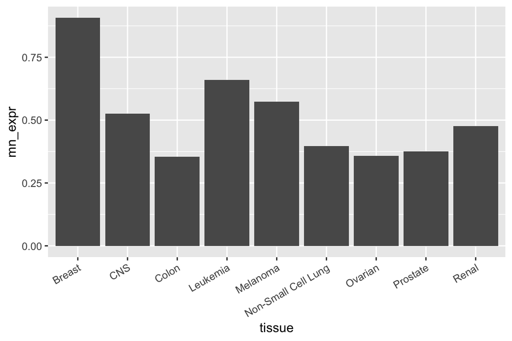

```r
## restrict data to include only the TOP3A probes
Probe_TOP3A <-
  Narrow %>% filter(Probe == "TOP3A")

## calculate mean expression (note: `exp(x)` is syntax for e^x where "e" is Euler's number: approx. 2.718)
SummaryStats <-
  Probe_TOP3A %>%
  group_by(tissue) %>%
  summarise(mn_expr = exp(mean(expression, na.rm = TRUE)))

## Inspect the result (reproduce Table 18.8)
# kable(SummaryStats)

## Bar chart of mean expression of TOP3A (Figure 18.1)
SummaryStats %>%
  ggplot(aes(x = tissue, y = mn_expr)) +
  geom_bar(stat = "identity") +
  theme(axis.text.x = element_text(angle = 30, hjust = 1))
```

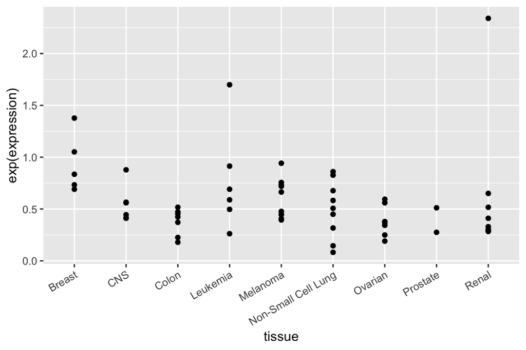

```r
## dot plot of mean expression of TOP3A (Figure 18.2)
Probe_TOP3A %>%
  ggplot(aes(x = tissue, y = exp(expression))) +
  geom_point() +
  theme(axis.text.x = element_text(angle = 30, hjust = 1))
```

##### Critique of Figure 18.1

Some of the shortcomings of Figure 18.1 might include: * bars alone may oversimplify the data leading to misinterpretation * may be useful to order the bars by height to facilitate tissue comparisons * precision of the estimate is not shown * too much ink for not much info

##### Improving the graphic

1. Lighten up the color using `alpha = 0.2` or perhaps switch to a dot plot (i.e. Figure 18.2)
2. Reorder the tissue types
3. Show statistical measure of variation

```r
## Calculate mean, standard error, and confidence interval
SummaryStats <-
  Probe_TOP3A %>%
  group_by(tissue) %>%
  summarise(mn = mean(expression, na.rm = TRUE),
            se = sd(expression, na.rm = TRUE) / sqrt( n() ))
```

4. Show the expression value for each of the individual cases in `MyProbe` (i.e. `TOP3A` here)
5. Use different modality, e.g. dot plot, box plot (`notch = TRUE`), violin plot

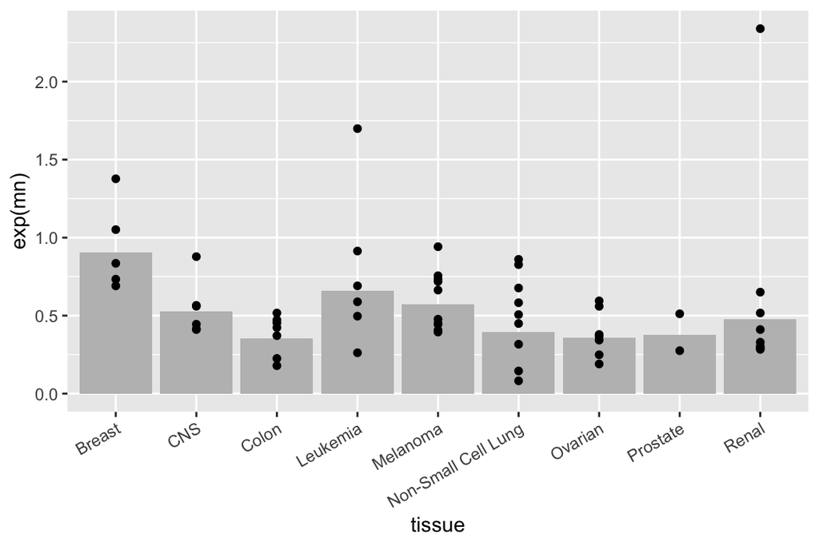

```r
SummaryStats %>%
  ggplot(aes(x = tissue, y = exp(mn))) +
  geom_bar(stat = "identity", fill = "gray", color = NA) +
  geom_point(data = Probe_TOP3A, aes(x = tissue, y = exp(expression))) +
  theme(axis.text.x = element_text(angle = 30, hjust = 1))
```

##### Reproduce “Dynamite Plot” in Figure 18.4

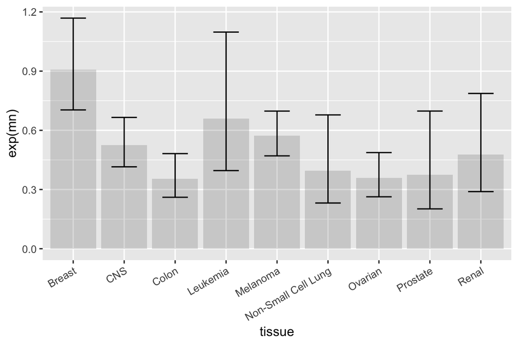

```r
## Calculate mean, standard error, and confidence interval
SummaryStats <-
  SummaryStats %>%
  mutate(top = mn + 2 * se,
         bottom = mn - 2 * se)


## "Dynamite Plot"
SummaryStats %>%
  ggplot(aes(x = tissue, y = exp(mn))) +
  geom_bar(stat = "identity", alpha = 0.2) +
  geom_errorbar(aes(x = tissue,
                    ymax = exp(top),
                    ymin = exp(bottom)), width = 0.5) +
  theme(axis.text.x = element_text(angle = 30, hjust = 1))
```

##### Reproduce Dot Plot with Confidence Intervals (Figure 18.5)

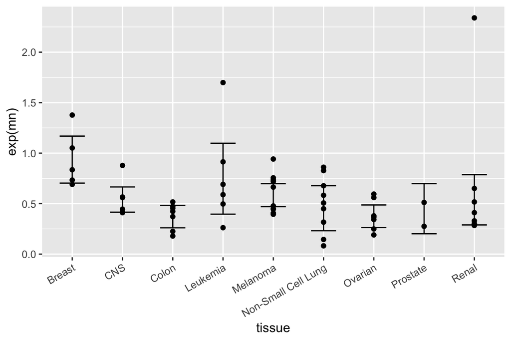

```r
SummaryStats %>%
  ggplot(aes(x = tissue, y = exp(mn))) +
  geom_errorbar(aes(x = tissue,
                    ymax = exp(top),
                    ymin = exp(bottom)), width = 0.5) +
  geom_point(data = Probe_TOP3A, aes(x = tissue, y = exp(expression))) +
  theme(axis.text.x = element_text(angle = 30, hjust = 1))
```

##### Your Turn: Pick a different probe and replicate Figure 18.5

[varies]

### Probing for a Probe

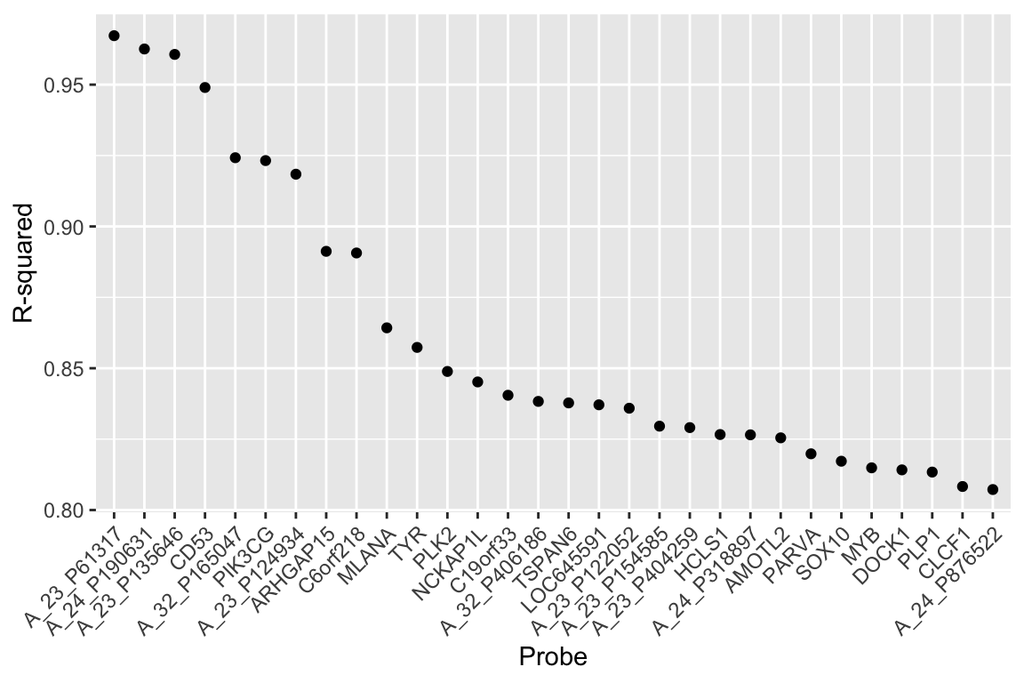

```r
## Order the Probes by R2, and pull out the 30 largest
Actual <-
  ProbeR2 %>%
  arrange(desc(r2)) %>%
  head(30)

## Show as a table
# kable(Actual)

## Graph probes with top 30 r-squared
Actual %>%
  ggplot(aes(x = reorder(Probe, desc(r2)), y = r2)) +
  geom_point() +
  theme(axis.text.x = element_text(angle = 45, hjust = 1)) +
  xlab("Probe") +
  ylab("R-squared")
```

### Your Turn: Choose a probe with high r-squared and create a plot like Figure A.10

I chose to investigate probe PLK2 (for no particular reason). A noteworthy difference between the plot associated with PLK2 and Figure A.10 based on TOP3A, is that there is a much more apparent association between certain tissue types and the probe. Namely, the probe is much more common among renal tissue by compasion to the other tissue types studied.

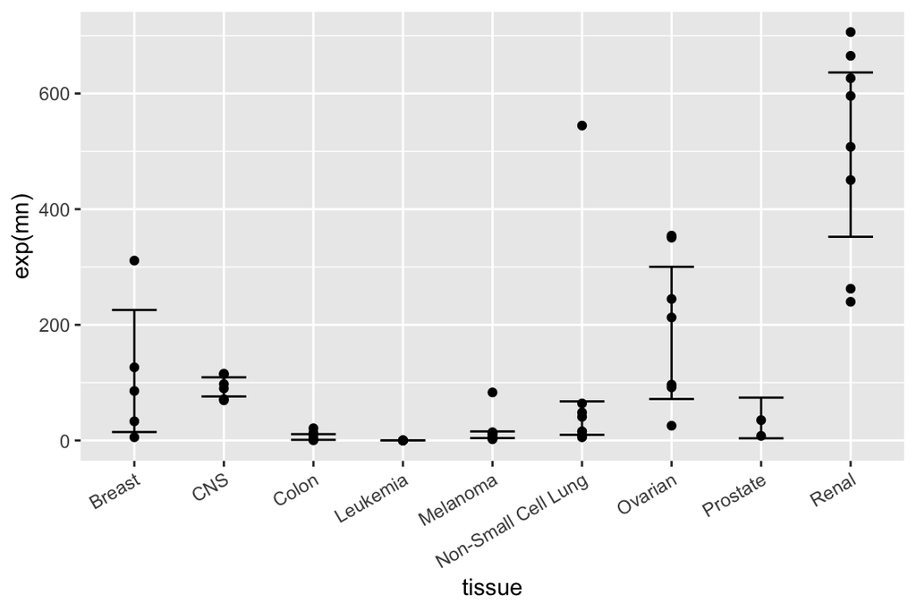

```r
## I selected Probe PLK2, but any probe from the top 30 is fine.
Probe_PLK2 <-
  Narrow %>% filter(Probe == "PLK2")

## Calculate mean, standard error, and confidence interval
SummaryStats_PLK2 <-
  Probe_PLK2 %>%
  group_by(tissue) %>%
  summarise(mn = mean(expression, na.rm = TRUE),
            se = sd(expression, na.rm = TRUE) / sqrt( n() )) %>%
  mutate(top = mn + 2 * se,
         bottom = mn - 2 * se)

## Reproduce Figure A.10 for Probe PLK2
SummaryStats_PLK2 %>%
  ggplot(aes(x = tissue, y = exp(mn))) +
  geom_errorbar(aes(x = tissue,
                    ymax = exp(top),
                    ymin = exp(bottom)), width = 0.5) +
  geom_point(data = Probe_PLK2, aes(x = tissue, y = exp(expression))) +
  theme(axis.text.x = element_text(angle = 30, hjust = 1))
```

### False Discoveries

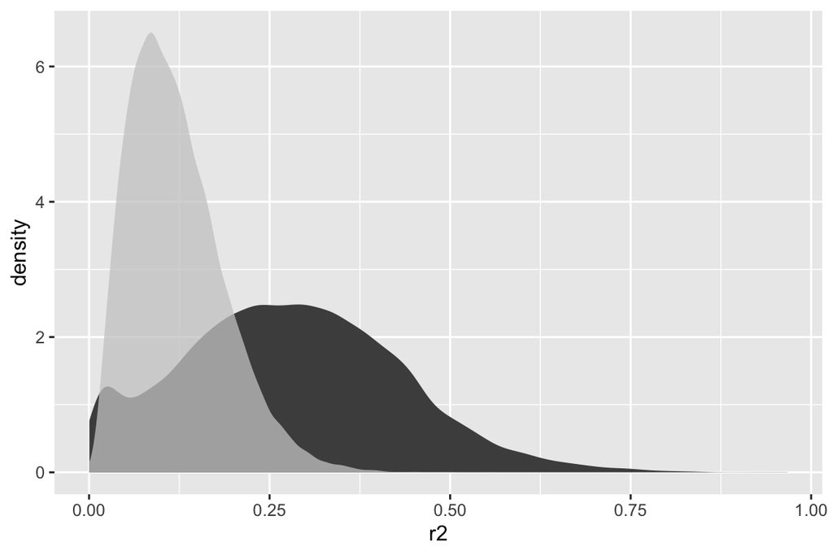

```r
##  Comparison of null distibution to the R2 observed for the actual data
ProbeR2 %>%
  ggplot(aes(x = r2)) +
  geom_density(fill = "gray30", color = NA) +
  geom_density(data = NullR2, aes(x = r2),
               fill = "gray80", alpha = 0.75, color = NA)
```

Lastly, we compare the top 30 observed r-squared values with the top 30 values produced in the null distribution. Since we generated the null distrubtion using random simulations (via `mosaic::shuffle()`), your results need not be identical to the picture in the book. In fact they may appear slightly different each time you refresh the analysis! Even still, the conclusion holds that none of the top 30 r-squared values for the actual data lie anywhere near those from the null hypothesis.

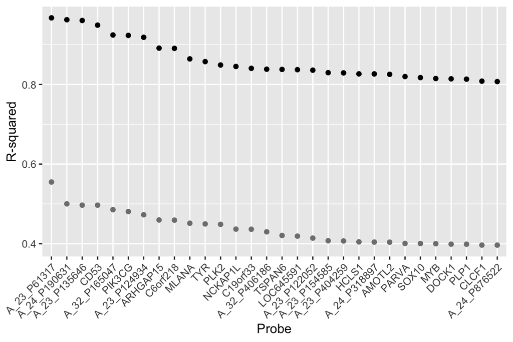

```r
Null <-
  NullR2 %>%
  arrange(desc(r2)) %>%
  head(30)

Actual$null <- Null$r2

Actual %>%
  ggplot(aes(x = reorder(Probe, desc(r2)), y = r2)) +
  geom_point() +
  geom_point(aes(y = null), color = "gray50") +
  theme(axis.text.x = element_text(angle = 45, hjust = 1)) +
  xlab("Probe") +
  ylab("R-squared")
```